# OBJECTIF 1 : Statistiques avec R

AFROMPA’R Bouaké 2025

Auteur·rice

Claude Grasland

Date de publication

2025-03-28

On se propoe de montrer l’intérêt de R pour l’enseignement de la statistique aux étudiants de licence de géographie… Cet exercice correspond typiquement au travail qu’on pourrait donner à des étudiants de licence 2 ou 3 ayant suivi des cours de statistique univariée et bivariée et ayant des connaissances de base en cartographie thématique.

```r
library(sf)
library(dplyr)
```

## (1) PREPARATION DES DONNEES STATISTIQUES

```r
# Importe les données
tab1<-read.table("data/exo_stats/idh1992.csv",
                dec=".",
                sep = ";",
                header=TRUE)
tab2<-read.table("data/exo_stats/idh2022.csv",
                dec=".",
                sep=";",
                header=TRUE)

# Sélectionne les variables
tab1 <- tab1 %>% select(code=code, pays=pays, nom=nom, pop1992 = pop, idh1992 = idh)
tab2 <- tab2 %>% select(code=code,  pop2022 = pop, idh2022 = idh)

# Fusionne les deux tableaux
don <- left_join(tab1,tab2)


# Affiche
library(knitr)
kable(don,
      main = "Tableau de départ")
```

| code | pays | nom | pop1992 | idh1992 | pop2022 | idh2022 |
| --- | --- | --- | --- | --- | --- | --- |
| CIVr101 | CIV | Abidjan | 2728 | 0.564 | 5984 | 0.569 |
| CIVr102 | CIV | Yamoussoukro | 112 | 0.623 | 245 | 0.619 |
| CIVr103 | CIV | Bas Sassandra | 529 | 0.406 | 1160 | 0.520 |
| CIVr104 | CIV | Comoe | 749 | 0.378 | 1642 | 0.582 |
| CIVr105 | CIV | Denguele | 381 | 0.332 | 836 | 0.440 |
| CIVr106 | CIV | Goh-Djiboua | 686 | 0.424 | 1504 | 0.551 |
| CIVr107 | CIV | Lacs | 1098 | 0.389 | 2409 | 0.542 |
| CIVr108 | CIV | Lagunes | 1023 | 0.456 | 2245 | 0.566 |
| CIVr109 | CIV | Montagnes | 1365 | 0.380 | 2994 | 0.492 |
| CIVr110 | CIV | Sassandra-Marahoue | 1614 | 0.407 | 3541 | 0.512 |
| CIVr111 | CIV | Savanes | 628 | 0.409 | 1376 | 0.471 |
| CIVr112 | CIV | Vallee du Bandama | 520 | 0.443 | 1140 | 0.554 |
| CIVr113 | CIV | Woroba | 574 | 0.199 | 1259 | 0.423 |
| CIVr114 | CIV | Zanzan | 834 | 0.320 | 1829 | 0.491 |

## (2) STATISTIQUE UNIVARIEE

### Paramètres principaux

- **Consigne** : Etudiez l’évolution de l’IDH entre 1992 et 2022 en vous servant de paramètres principaux (valeurs centrales, paramètres de dispersion). Puis établissez deux histogrammes permettant de visualiser l’évolution.

```r
# sélectionne les variables
sel <- don[,c("idh1992","idh2022")]

# Tableau standard
quant<-apply(sel,2,quantile)
moy<-apply(sel,2,mean)
ect<-apply(sel,2,sd)
cv<-100*ect/moy
tab<-rbind(quant,moy,ect,cv)
row.names(tab) <-c("Minimum","Q1","Médiane","Q3","Maximum","Moyenne","Ecart-type", "C.V. (%)")

kable(tab, caption="Paramètres principaux", digits =2,
      col.names = c("Situation en 1992","Situation en 2022"),
      )
```

Paramètres principaux

|  | Situation en 1992 | Situation en 2022 |
| --- | --- | --- |
| Minimum | 0.20 | 0.42 |
| Q1 | 0.38 | 0.49 |
| Médiane | 0.41 | 0.53 |
| Q3 | 0.44 | 0.56 |
| Maximum | 0.62 | 0.62 |
| Moyenne | 0.41 | 0.52 |
| Ecart-type | 0.10 | 0.06 |
| C.V. (%) | 24.77 | 10.65 |

### Histogrammes

- **Consigne** : Etablissez deux histogrammes permettant de visualiser la forme de la distribution de l’IDH en 1992 et en 2022

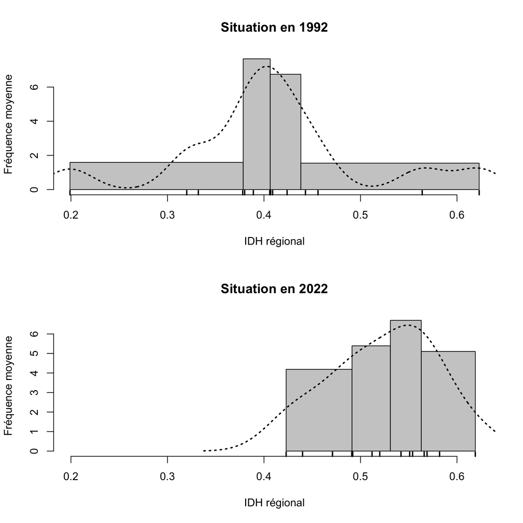

```r
par(mfrow=c(2,1))

mintot <-min(c(sel$idh1992, sel$idh2022))
maxtot <-max(c(sel$idh1992, sel$idh2022))

# Histogramme
hist(sel$idh1992,
     breaks=quantile(sel$idh1992),
     xlim=c(mintot,maxtot),
     col="gray80",
     main= "Situation en 1992",
     xlab = "IDH régional",
     ylab = "Fréquence moyenne")
rug(sel$idh1992, col="black", lwd=2)
lines(density(sel$idh1992), lty=3,lwd=2)

hist(sel$idh2022,
     breaks=quantile(sel$idh2022),
     xlim=c(mintot,maxtot),
     col="gray80",
     main= "Situation en 2022",
     xlab = "IDH régional",
     ylab = "Fréquence moyenne")
rug(sel$idh2022, col="black", lwd=2)
lines(density(sel$idh2022), lty=3,lwd=2)
```

## (3) PREPARATION DES DONNEES GEOMETRIQUES

- **Consigne** : Après avoir chargé le fonds de carte affichez le contour des régions et le code des unités.

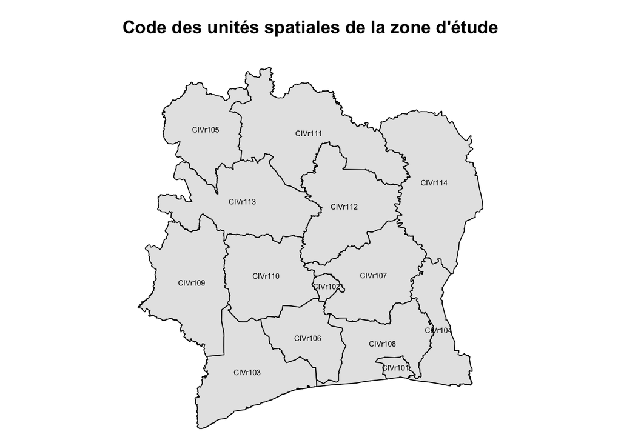

```r
# Importe le fonds de carte
map <- st_read("data/exo_stats/mapreg.shp")
# Projette
map <- st_transform(map, 2042)


# Affichage du fonds de carte
par(mar=c(0,0,3,0))
plot(map$geometry,
     col="gray90",
     main = "Code des unités spatiales de la zone d'étude")

# Ajout du code des unités spatiales
coo<-st_coordinates(st_centroid(map))
text(coo, map$code, cex=0.5,col="black",)
```

## (4) CARTOGRAPHIE THEMATIQUE

### Cartes de stock

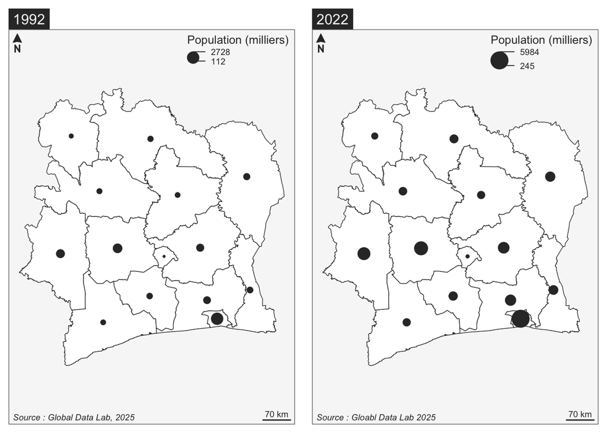

```r
library(mapsf)
map<-map[,c("code","geometry")]
map_don <- merge(map, don, by="code")

maxequ<-max(don$pop012,don$pop2022)

par(mfrow=c(1,2))
mf_map(map_don$geometry, col="white")
mf_map(map_don, type="prop", var="pop1992",
       val_max = maxequ, inches=0.1, col="gray20",
       leg_title = "Population (milliers)",)
mf_layout(title="1992",frame = T, credits = "Source : Global Data Lab, 2025")

mf_map(map_don$geometry, col="white")
mf_map(map_don, type="prop", var="pop2022",
       val_max = maxequ, inches=0.1, col="gray20",
       leg_title = "Population (milliers)")
mf_layout(title="2022",frame = T, credits = "Source : Gloabl Data Lab 2025")
```

### Cartes de ratio (choroplèthes)

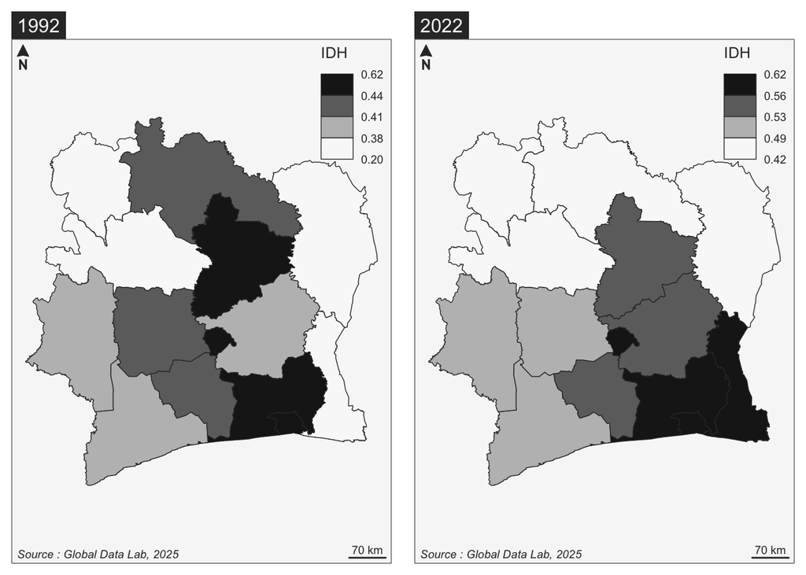

```r
library(mapsf)
map_don <- merge(map, don, by="code")
maxequ<-max(don$hdi2002,don$hdi2022)

par(mfrow=c(1,2))
mf_map(map_don, type="choro", var="idh1992",
       breaks = "quantile",nbreaks = 4, pal ="Grays",
       leg_title = "IDH",leg_val_rnd = 2)
mf_layout(title="1992",frame = T, credits = "Source : Global Data Lab, 2025")

mf_map(map_don, type="choro", var="idh2022",
       breaks = "quantile",nbreaks = 4, pal ="Grays",
       leg_title = "IDH",leg_val_rnd = 2)
mf_layout(title="2022",frame = T, credits = "Source : Global Data Lab, 2025")
```

## (5) STATISTIQUES BIVARIEES

### Nuage de points

- **Consigne** : Tracez un nuage de point montrant l’évolution de l’indicateur de développement humain entre les deux dates.

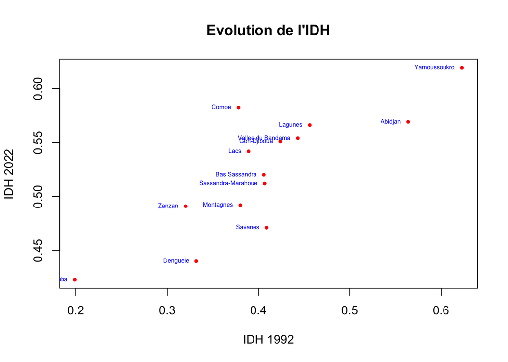

```r
# prépration de l'analyse
code<-don$code
nom<-don$nom
X<-don$idh1992
Y<-don$idh2022
tab<-data.frame(code,nom,X,Y)

# Diagramme
plot(tab$X,tab$Y,
     pch=20,
     cex=0.8,
     col="red",
     main = "Evolution de l'IDH",
     xlab="IDH 1992",
     ylab ="IDH 2022")
text(tab$X,tab$Y,tab$nom,
     pos=2,
     cex=0.5,
     col="blue")
```

### Analyse de la corrélation

- **Consigne** : calculez les coefficients de corrélation de Pearson et Spearman et testez leur sgnificativité.

```r
cor.test(X,Y, method="pearson")
```

```
    Pearson's product-moment correlation

data:  X and Y
t = 4.9223, df = 12, p-value = 0.0003524
alternative hypothesis: true correlation is not equal to 0
95 percent confidence interval:
 0.5073463 0.9403486
sample estimates:
      cor
0.8177876
```

```r
cor.test(X,Y, method="spearman")
```

```
    Spearman's rank correlation rho

data:  X and Y
S = 134, p-value = 0.006405
alternative hypothesis: true rho is not equal to 0
sample estimates:
      rho
0.7054945
```

### Droite de régression

- **Consigne** : calculez l’equation de la droite de régression et tracez- là sur le graphique.

```r
modreg <- lm(Y~X)
summary(modreg)
```

```
Call:
lm(formula = Y ~ X)

Residuals:
      Min        1Q    Median        3Q       Max
-0.052586 -0.016570 -0.001574  0.019274  0.072368

Coefficients:
            Estimate Std. Error t value Pr(>|t|)
(Intercept)  0.33948    0.03848   8.823 1.36e-06 ***
X            0.45013    0.09145   4.922 0.000352 ***
---
Signif. codes:  0 '***' 0.001 '**' 0.01 '*' 0.05 '.' 0.1 ' ' 1

Residual standard error: 0.03342 on 12 degrees of freedom
Multiple R-squared:  0.6688,    Adjusted R-squared:  0.6412
F-statistic: 24.23 on 1 and 12 DF,  p-value: 0.0003524
```

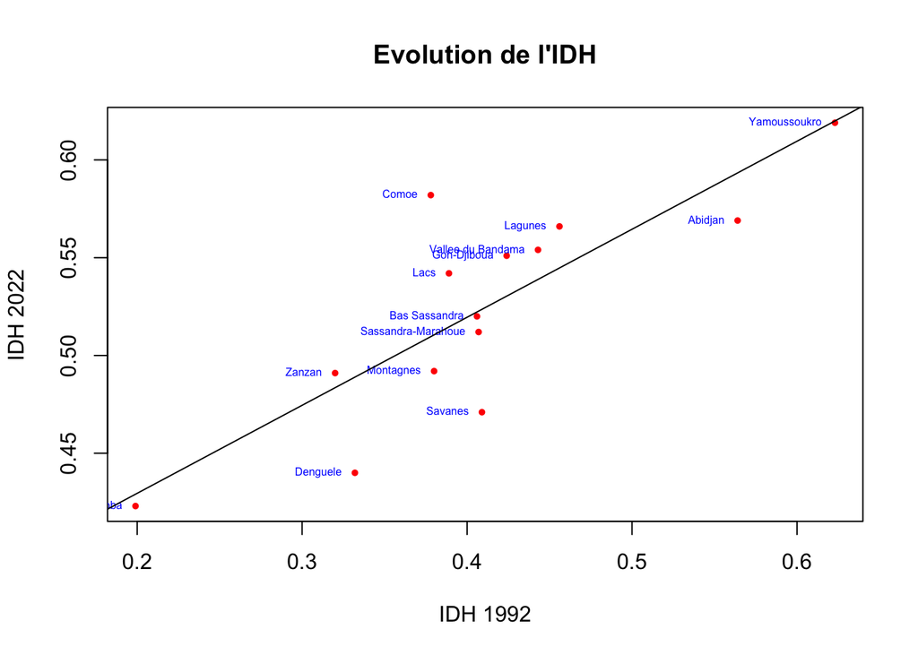

```r
# Diagramme
plot(tab$X,tab$Y,
     pch=20,
     cex=0.8,
     col="red",
     main = "Evolution de l'IDH",
     xlab="IDH 1992",
     ylab ="IDH 2022")
text(tab$X,tab$Y,tab$nom,
     pos=2,
     cex=0.5,
     col="blue")

abline(modreg,col="black",lwd=1)
```

### Analyse des résidus

- **Consigne** : Calculez les valeurs théoriques prévus par le modèle de régression et les résidus. Affichez le tableau correspondant après l’avoir trié par ordre de résidus croissants.

```r
tab$Y_est <- modreg$fitted.values
tab$Y_res <- modreg$residuals
tab<-tab[order(tab$Y_res),]
kable(tab, digits=3)
```

|  | code | nom | X | Y | Y_est | Y_res |
| --- | --- | --- | --- | --- | --- | --- |
| 11 | CIVr111 | Savanes | 0.409 | 0.471 | 0.524 | -0.053 |
| 5 | CIVr105 | Denguele | 0.332 | 0.440 | 0.489 | -0.049 |
| 1 | CIVr101 | Abidjan | 0.564 | 0.569 | 0.593 | -0.024 |
| 9 | CIVr109 | Montagnes | 0.380 | 0.492 | 0.511 | -0.019 |
| 10 | CIVr110 | Sassandra-Marahoue | 0.407 | 0.512 | 0.523 | -0.011 |
| 13 | CIVr113 | Woroba | 0.199 | 0.423 | 0.429 | -0.006 |
| 3 | CIVr103 | Bas Sassandra | 0.406 | 0.520 | 0.522 | -0.002 |
| 2 | CIVr102 | Yamoussoukro | 0.623 | 0.619 | 0.620 | -0.001 |
| 14 | CIVr114 | Zanzan | 0.320 | 0.491 | 0.484 | 0.007 |
| 12 | CIVr112 | Vallee du Bandama | 0.443 | 0.554 | 0.539 | 0.015 |
| 6 | CIVr106 | Goh-Djiboua | 0.424 | 0.551 | 0.530 | 0.021 |
| 8 | CIVr108 | Lagunes | 0.456 | 0.566 | 0.545 | 0.021 |
| 7 | CIVr107 | Lacs | 0.389 | 0.542 | 0.515 | 0.027 |
| 4 | CIVr104 | Comoe | 0.378 | 0.582 | 0.510 | 0.072 |

### Cartographie des résidus

- **Consigne** : Cartographiez les résidus après les avoir standardisés.

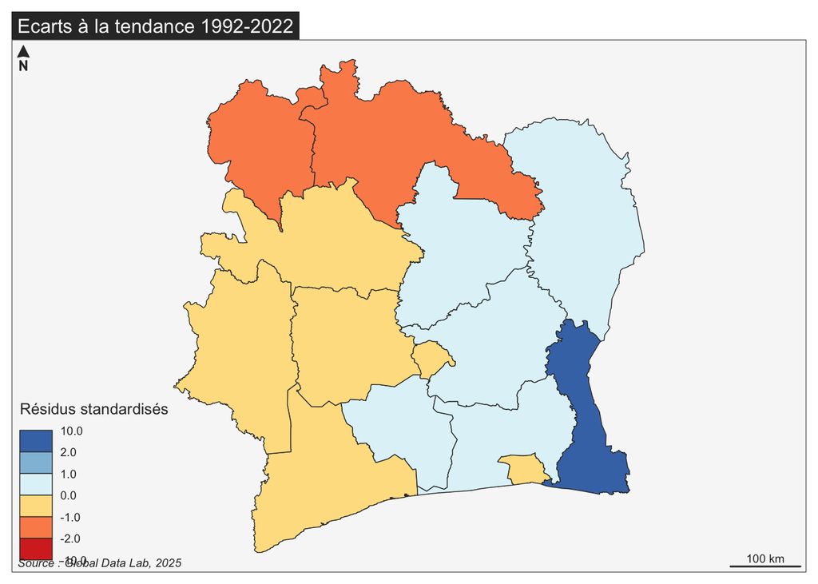

```r
library(mapsf)

# Standardisation des résidus
tab$Y_res_std<-tab$Y_res/sd(tab$Y_res)

# Jointure avec la carte
map<-map[,c("code","geometry")]
map_reg <- merge(map, tab, by="code")

# Choix de la palette et des classes
library(RColorBrewer)
mypal<-brewer.pal(n = 6, name = "RdYlBu")
mybreaks = c(-10, -2,-1,0,1,2,10)

mf_map(map_reg, type="choro", var="Y_res_std",
       pal = mypal, breaks=mybreaks,
       leg_title = "Résidus standardisés",leg_val_rnd = 1)
mf_layout(title="Ecarts à la tendance 1992-2022",frame = T, credits = "Source : Global Data Lab, 2025")
```

## (6) ANALYSE SPATIALE

On se propose d’analyser l’effet de la distance à la capitale économique (Abidjan) ou politique (Yamoussoukro) sur l’évolution de lIDH entre 1992 et 2022

### Distance aux deux capitales.

- **Consigne** : ajoutez au tableau de données une colonne correspondant à la distance en km à Abidjan ou Yamoussoukro et faites en une cartographie en prenant comme bornes de classes 0, 100, 200, 300, 400, 500, 1000 km.

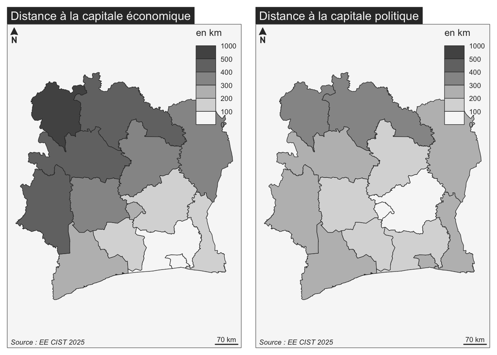

```r
map_don$capeco<-0
map_don$capeco[1]<-1
capeco<-map_don[map_don$capeco==1,]
map_don$distcapeco<-1+as.numeric(st_distance(st_centroid(map_don),st_centroid(capeco)))/1000

map_don$cappol<-0
map_don$cappol[2]<-1
cappol<-map_don[map_don$cappol==1,]
map_don$distcappol<-1+as.numeric(st_distance(st_centroid(map_don),st_centroid(cappol)))/1000



# Choix de la palette et des classes
mypal<-brewer.pal(n = 7, name = "Greys")
mybreaks = c(0,100,200,300,400,500, 1000)

par(mfrow=c(1,2))
mf_map(map_don, type="choro", var="distcapeco",
       pal = mypal, breaks=mybreaks,
       leg_title = "en km",leg_val_rnd = 0)
mf_layout(title="Distance à la capitale économique",frame = T, credits = "Source : EE CIST 2025")

mf_map(map_don, type="choro", var="distcappol",
       pal = mypal, breaks=mybreaks,
       leg_title = "en km",leg_val_rnd = 0)
mf_layout(title="Distance à la capitale politique",frame = T, credits = "Source : EE CIST 2025")
```

### Relation entre développement et distance à la capitale

- **Consigne** : Etudiez les corrélations entre l’IDH en 1992 (Y1) ou 2022 (Y2) et la distance à la capitale économique (X1) ou politique (X2). Que pouvez-vous en conclure ?

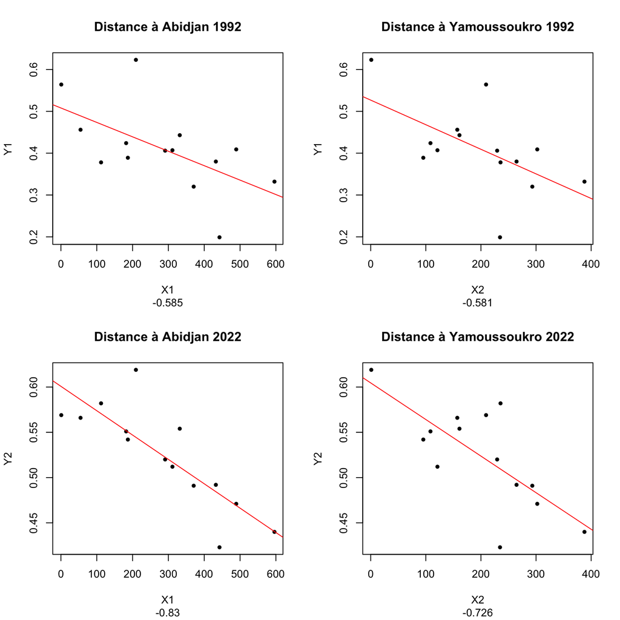

```r
X1<-map_don$distcapeco
X2<-map_don$distcappol
Y1<-map_don$idh1992
Y2<-map_don$idh2022

par(mfrow=c(2,2))
plot(X1,Y1,main="Distance à Abidjan 1992", sub = round(cor(X1,Y1),3), pch=20)
abline(lm(Y1~X1),col="red")
plot(X2,Y1, main = "Distance à Yamoussoukro 1992",sub = round(cor(X2,Y1),3),pch=20)
abline(lm(Y1~X2),col="red")
plot(X1,Y2,main="Distance à Abidjan 2022", sub = round(cor(X1,Y2),3), pch=20)
abline(lm(Y2~X1),col="red")
plot(X2,Y2, main = "Distance à Yamoussoukro 2022",sub = round(cor(X2,Y2),3),pch=20)
abline(lm(Y2~X2),col="red")
```